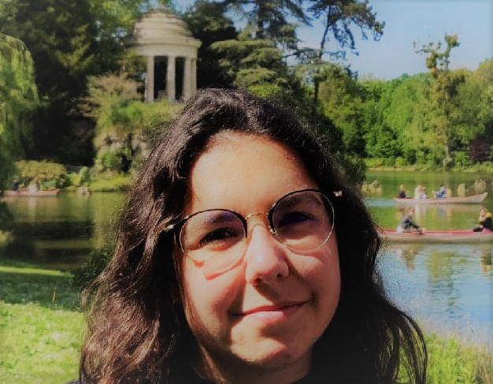

# Léonie Courcoul

## Bio

Hi ! I’m Léonie Courcoul. I am a PhD student in Biostatistics at the [University of Bordeaux (France)](https://www.u-bordeaux.fr/), in the [Biostatistic team](https://www.bordeaux-population-health.center/les-equipes/biostatistique/) from [Bordeaux Population Health Center (INSERM U1219)](https://www.bordeaux-population-health.center/en/) since November 2021. I do my research under the supervision of Hélène Jacqmin-Gadda and [Antoine Barbieri](https://antoinebarbieri.netlify.app/). My thesis work are focused on the development of statistical models to study the impact of the variability of blood pressure on the risk of various clinical events such as stroke and dementia.

## Education

- [**Bordeaux Population Health Center (INSERM U1219)**](https://www.bordeaux-population-health.center/en/) | Bordeaux, FRANCE

Ph.D. in Biostatistics | November 2021 - now

- [**ENSAI**](https://ensai.fr/en/) | Bruz, FRANCE

Engineer in Data Science with a specialisation in Biostatistics | 2018 - 2021

- [**University of Rennes 1**](https://formations.univ-rennes.fr/master-mention-bio-informatique-parcours-informatique-pour-la-biologie-et-la-sante-ibisa) | Rennes, FRANCE

MSc in Bioinformatic | 2020 - 2021

## Professional experiences

[**Bordeaux Population Health Center (INSERM U1219)**](https://www.bordeaux-population-health.center/en/) | Bordeaux, FRANCE

PhD Student | November 2021 - Present

## Publications

- **Courcoul L**, Tzourio C, Woodward M, Barbieri A, Jacqmin-Gadda H. **A location-scale joint model for studying the link between the time-dependent subject-specific variability of blood pressure and competing events.** 2023. [[ArXiv]](https://arxiv.org/abs/2306.16785)

## Communications

- **Oral presentation - SAFJR 2023** | Ulm, Germany | Sept 2023
- **Oral presentation - Student award - ISCB 2023** | Milan, Italy | Aug 2023
- **Oral presentation - French Biostatistic Days** | Rennes, France | Dec 2022
- **Poster - ISH** | Japan (remote) | Oct 2022
- **Oral presentation - IBC 2022** | Riga, Latvia | July 2022
- **Oral presentation - JDS 2022** | Lyon, France | June 2022

## Software

- **FlexVarJM** is a downloadable R-package from GitHub. This package concerns the estimation of a joint model with subject-specific time-dependent variability [[GitHub]](https://github.com/LeonieCourcoul/FlexVarJM)